# Prediction Assignment

Shraddha

June 10, 2016

Loading required libraries

```r
library(caret)
```

```r
library(rpart)
library(rpart.plot)
library(rattle)
library(randomForest)
library(e1071)
set.seed(1)
```

## Loading and Cleaning the data

Loading the data by deleting the columns with missing values and irrelevant values

```r
training<-read.csv("F:/pml-training.csv",header=TRUE,na.strings=c("NA","#DIV/0!",""))
testing<-read.csv("F:/pml-testing.csv",header=TRUE,na.strings=c("NA","#DIV/0!",""))
dim(training)
```

```
## [1] 19622   160
```

```r
dim(testing)
```

```
## [1]  20 160
```

Now we check the number of variables and observations and then deleting the columns with missing values

```r
trainingData<- training[,colSums(is.na(training))==0]
testingData<- testing[,colSums(is.na(testing))==0]
```

#Now removing irrelevant variables - user_name,raw_timestamp_part_1,raw_timestamp_part_2,cvtd_timestamp,new_window,num_window i.e. columns 1 to 7 and again checking the number of variables and observations in teh new data set

```r
trainingData<- trainingData[,-c(1:7)]
testingData<- testingData[,c(1:7)]

dim(trainingData)
```

```
## [1] 19622    53
```

```r
dim(testingData)
```

```
## [1] 20  7
```

## Partitioning the Training Dataset

Since there are 19622 observations in training set, partition the training dataset into sets trainingNew (70%) and testingNew(30%)

```r
inTrain<- createDataPartition(y=trainingData$classe,p=0.7,list=FALSE)
trainingNew<- trainingData[inTrain,]
testingNew<- trainingData[-inTrain,]
dim(trainingNew)
```

```
## [1] 13737    53
```

```r
dim(testingNew)
```

```
## [1] 5885   53
```

Two methods - Decision Tree and Random Forest will be applied to the the training data set and the best model with high accuracy will be applied to the test data set.

## Decision Tree - First prediction model

```r
Fit1<- rpart(classe~.,data=trainingNew,method="class")
```

Predicting Model 1

```r
prediction1<- predict(Fit1, testingNew, type="class")
```

Plotting the Decision tree

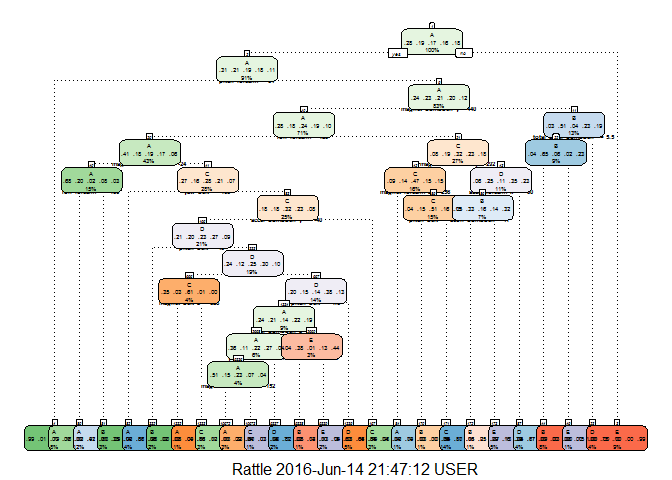

```r
fancyRpartPlot(Fit1,cex=0.4,under.cex=1,shadow.offset=0)
```

Testing results on testingNew data set

```r
library(e1071)
confusionMatrix(prediction1, testingNew$classe)
```

```
## Confusion Matrix and Statistics
##
##           Reference
## Prediction    A    B    C    D    E
##          A 1473  160   24   44   15
##          B   55  699   56   73  101
##          C   57  121  818  161  132
##          D   56   82   60  609   53
##          E   33   77   68   77  781
##
## Overall Statistics
##
##                Accuracy : 0.7443
##                  95% CI : (0.7329, 0.7554)
##     No Information Rate : 0.2845
##     P-Value [Acc > NIR] : < 2.2e-16
##
##                   Kappa : 0.6764
##  Mcnemar's Test P-Value : < 2.2e-16
##
## Statistics by Class:
##
##                      Class: A Class: B Class: C Class: D Class: E
## Sensitivity            0.8799   0.6137   0.7973   0.6317   0.7218
## Specificity            0.9423   0.9399   0.9031   0.9490   0.9469
## Pos Pred Value         0.8584   0.7104   0.6346   0.7081   0.7539
## Neg Pred Value         0.9518   0.9102   0.9547   0.9294   0.9379
## Prevalence             0.2845   0.1935   0.1743   0.1638   0.1839
## Detection Rate         0.2503   0.1188   0.1390   0.1035   0.1327
## Detection Prevalence   0.2916   0.1672   0.2190   0.1461   0.1760
## Balanced Accuracy      0.9111   0.7768   0.8502   0.7904   0.8344
```

## Random Forest - Second Prediction Model

```r
Fit2<- randomForest(classe~., data=trainingNew,method="class")
```

Predicting Model 2

```r
prediction2<- predict(Fit2, testingNew, type="class")
```

Testing results on testingNew data set

```r
confusionMatrix(prediction2, testingNew$classe)
```

```
## Confusion Matrix and Statistics
##
##           Reference
## Prediction    A    B    C    D    E
##          A 1672    2    0    0    0
##          B    0 1136    7    0    0
##          C    1    1 1018    4    0
##          D    0    0    1  959    2
##          E    1    0    0    1 1080
##
## Overall Statistics
##
##                Accuracy : 0.9966
##                  95% CI : (0.9948, 0.9979)
##     No Information Rate : 0.2845
##     P-Value [Acc > NIR] : < 2.2e-16
##
##                   Kappa : 0.9957
##  Mcnemar's Test P-Value : NA
##
## Statistics by Class:
##
##                      Class: A Class: B Class: C Class: D Class: E
## Sensitivity            0.9988   0.9974   0.9922   0.9948   0.9982
## Specificity            0.9995   0.9985   0.9988   0.9994   0.9996
## Pos Pred Value         0.9988   0.9939   0.9941   0.9969   0.9982
## Neg Pred Value         0.9995   0.9994   0.9984   0.9990   0.9996
## Prevalence             0.2845   0.1935   0.1743   0.1638   0.1839
## Detection Rate         0.2841   0.1930   0.1730   0.1630   0.1835
## Detection Prevalence   0.2845   0.1942   0.1740   0.1635   0.1839
## Balanced Accuracy      0.9992   0.9979   0.9955   0.9971   0.9989
```

## Conclusion:

Random Forest will be choosen as it has the higher accuracy 0.996, as compared to Decision Tree Model, which has an accuracy of 0.744. The expected out-of-sample error will be calculated by 1-accuracy for predictions made against the cross-validation set. Hence, the error rate on applying Random Forest algorithm will be 0.4%

Since the testing data set has only 20 cases, very few of the test samples will be missclassified.

Applying Random Forest algorithm to the origial Testing data set

```r
FinalPrediction<- predict(Fit2,testing,type="class")
FinalPrediction
```

```
##  1  2  3  4  5  6  7  8  9 10 11 12 13 14 15 16 17 18 19 20
##  B  A  B  A  A  E  D  B  A  A  B  C  B  A  E  E  A  B  B  B
## Levels: A B C D E
```

## Creating Submission files

```r
pmlWriteFiles<- function(x)
{
n=length(x)
for(i in 1:n)
{
filename=paste0("E:/",i,".txt")
write.table(x[i],file=filename,quote=FALSE,row.names=FALSE,col.names=FALSE)
}
}
pmlWriteFiles(FinalPrediction)
```